# Regression Analysis Project

Aditya Parekh, Utkarsh Jhadav, Yassh Tyagi and Veer Shah

08/04/2023

# The objective set:

The objective of this study is to understand the relationship between house price of unit area and the other factors

# Importing Libraries

```r
library(DescTools)
library(lmtest)
```

We are loading the “DescTools” and “lmtest” library, which provide a collection of tools for descriptive statistics and data analysis.

```r
df<-read.csv('C:/Users/veers/Downloads/Real Estate.csv')
head(df)
```

|  | Transaction.date | House.age | Distance.to.the.nearest.MRT.station | Number.of.convenience.stores | Latitude | Longitude | House.price.of.unit.area |
| --- | --- | --- | --- | --- | --- | --- | --- |
| 1 | 2012 | 32.0 | 84.87882 | 10 | 24.98298 | 121.5402 | 37.9 |
| 2 | 2012 | 19.5 | 306.59470 | 9 | 24.98034 | 121.5395 | 42.2 |
| 3 | 2013 | 13.3 | 561.98450 | 5 | 24.98746 | 121.5439 | 47.3 |
| 4 | 2013 | 13.3 | 561.98450 | 5 | 24.98746 | 121.5439 | 54.8 |
| 5 | 2012 | 5.0 | 390.56840 | 5 | 24.97937 | 121.5425 | 43.1 |
| 6 | 2012 | 7.1 | 2175.03000 | 3 | 24.96305 | 121.5125 | 32.1 |

```r
dim(df)
```

```
## [1] 414   7
```

Reading a CSV file called “Real Estate.csv” from the specified directory using the read.csv() function and assigning it to a data frame called df.

Checking the dimensions of the df data frame using the dim() function, which returns the number of rows and columns in the data frame.

We have 414 rows and 7 columnsin our dataset.

```r
#Number of null values in each column.
colSums(is.na(df))
```

```
##                    Transaction.date                           House.age
##                                   0                                   0
## Distance.to.the.nearest.MRT.station        Number.of.convenience.stores
##                                   0                                   0
##                            Latitude                           Longitude
##                                   0                                   0
##            House.price.of.unit.area
##                                   0
```

We do not have any null value in our dataset.We have calculated the number of null values in each column of the df data frame using the colSums() function in combination with the is.na() function, which returns a vector of the same length as the number of columns in the data frame, with each number representing the number of missing values in the corresponding column. So we got 0 null values in each column.’

# Variable and their types

```r
sapply(df,typeof)
```

```
##                    Transaction.date                           House.age
##                           "integer"                            "double"
## Distance.to.the.nearest.MRT.station        Number.of.convenience.stores
##                            "double"                           "integer"
##                            Latitude                           Longitude
##                            "double"                            "double"
##            House.price.of.unit.area
##                            "double"
```

The discrete variables from the given output are: Number.of.convenience.stores and Transaction.date. The continuous variables from the given output are: House.age, Distance.to.the.nearest.MRT.station, Latitude, Longitude, and House.price.of.unit.area.

# Descirptions of variables :

The Regressor variables (X) are as follows:

1] Transaction.date(Nominal) - the year in which the transaction was made (integer)

2] House.age(Ordinal) - Age of the house (double)

3] Distance.to.the.nearest.MRT.station(Ordinal) - distance between the house and nearest metro station (double)

5] Latitude(Nominal) - Latitudinal co-ordinate of the house (double)

6] Longitude(Nominal) - Longitudinal co-ordinate of the house (double)

The Response variabe is (Y):

House.price.of.unit.area(Ordinal) - Price of per unit area of the house (Double)’

Unique years in the dataset

```r
unique(df$Transaction.date)
```

```
## [1] 2012 2013
```

The data in the data frame spans over two years(2012 & 2013).

Unique values in convenient store column in the dataset

```r
unique(df$Number.of.convenience.stores)
```

```
##  [1] 10  9  5  3  7  6  1  4  2  8  0
```

# A quick statistical summary of each column:

```r
summary(df)
```

```
##  Transaction.date   House.age      Distance.to.the.nearest.MRT.station
##  Min.   :2012     Min.   : 0.000   Min.   :  23.38
##  1st Qu.:2012     1st Qu.: 9.025   1st Qu.: 289.32
##  Median :2013     Median :16.100   Median : 492.23
##  Mean   :2013     Mean   :17.713   Mean   :1083.89
##  3rd Qu.:2013     3rd Qu.:28.150   3rd Qu.:1454.28
##  Max.   :2013     Max.   :43.800   Max.   :6488.02
##  Number.of.convenience.stores    Latitude       Longitude
##  Min.   : 0.000               Min.   :24.93   Min.   :121.5
##  1st Qu.: 1.000               1st Qu.:24.96   1st Qu.:121.5
##  Median : 4.000               Median :24.97   Median :121.5
##  Mean   : 4.094               Mean   :24.97   Mean   :121.5
##  3rd Qu.: 6.000               3rd Qu.:24.98   3rd Qu.:121.5
##  Max.   :10.000               Max.   :25.01   Max.   :121.6
##  House.price.of.unit.area
##  Min.   :  7.60
##  1st Qu.: 27.70
##  Median : 38.45
##  Mean   : 37.98
##  3rd Qu.: 46.60
##  Max.   :117.50
```

For the variable “Transaction.date”, it shows the minimum and maximum values, as well as the first, second (median), and third quartiles.

The same information is provided for the variables “House.age”, “Distance.to.the.nearest.MRT.station”, “Number.of.convenience.stores”, “Latitude”, “Longitude”, and “House.price.of.unit.area”.

From this summary, we can see that the “Transaction.date” column contains data only from the years 2012 and 2013.

The “House.age” column ranges from 0 to 43.8 years, with a median age of 16.1 years.

The “Distance.to.the.nearest.MRT.station” column has a large range, from 23.38 to 6488.02, and a median of 492.23 meters.

The “Number.of.convenience.stores” column ranges from 0 to 10, with a median of 4.

The “Latitude” column has a small range, from 24.93 to 25.01, and a median of 24.97.

The “Longitude” column has a small range, from 121.5 to 121.6, and a median of 121.5.

Finally, the “House.price.of.unit.area” column has a wide range, from 7.6 to 117.5, and a median of 38.45.

This summary provides a good overview of the range and distribution of the variables in the dataset .’

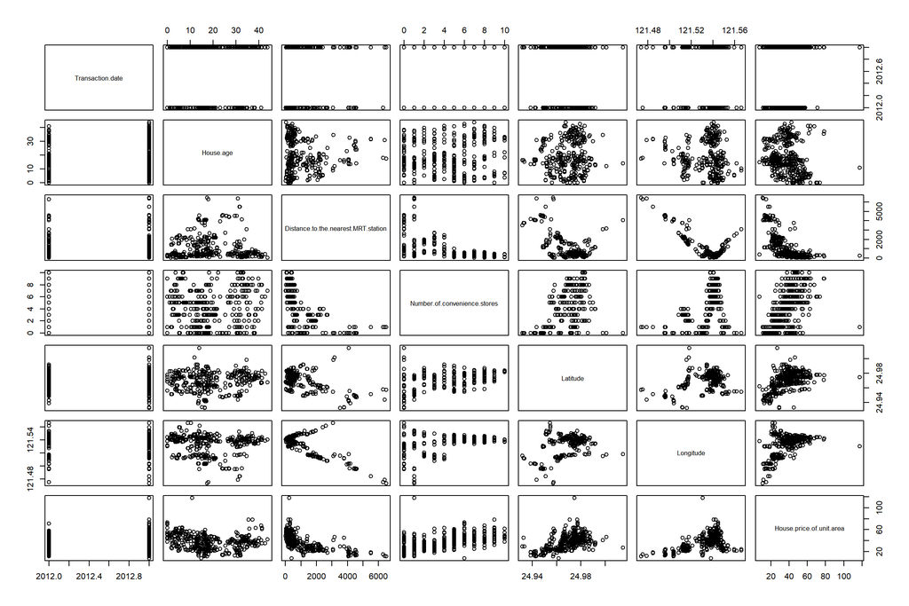

```r
plot(df)
```

# Outlier detection

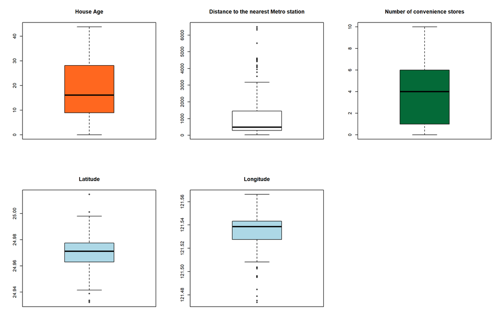

```r
par(mfrow = c(2,3))
boxplot(df$House.age, main = 'House Age', col= '#FF671F')
boxplot(df$Distance.to.the.nearest.MRT.station, main = "Distance to the nearest Metro station", col= 'white')
boxplot(df$Number.of.convenience.stores, main = 'Number of convenience stores', col='#046A38')
boxplot(df$Latitude, main = 'Latitude', col= 'lightblue')
boxplot(df$Longitude, main = 'Longitude', col= 'lightblue')
```

After examining the boxplots of each column, it can be observed that there are many outliers that cannot be simply removed from the dataset. Therefore, a data cleaning technique called “winsorizing” needs to be applied to address these outliers.

Winsorizing is a statistical method used to handle outliers. It involves replacing the values that exceed the extreme value thresholds with the limit values. These extreme values are identified by calculating a certain percentile of the data.For eg To provide an illustration,

applying a 90% winsorization to a dataset would imply that any data point that lies outside the 5th and 95th percentiles of the distribution will be replaced with the values of the 5th and 95th percentile data points, correspondingly.

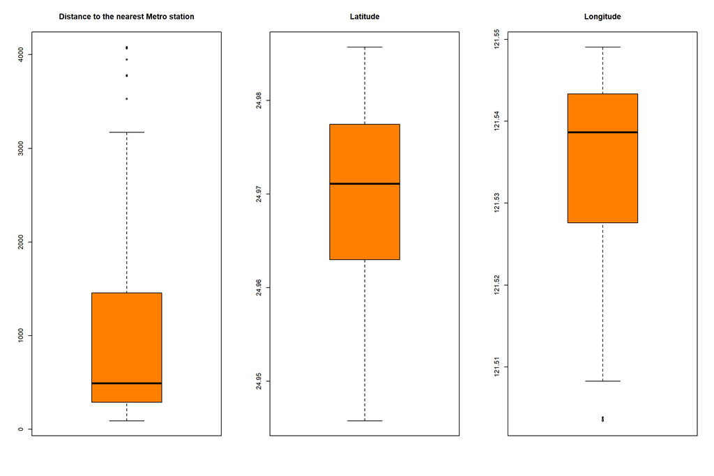

```r
par(mfrow = c(1,3))
df[1:6]<-lapply(df[1:6], Winsorize)
boxplot(df$Distance.to.the.nearest.MRT.station, main = "Distance to the nearest Metro station", col='#FF8000')
boxplot(df$Latitude, main = 'Latitude', col='#FF8000')
boxplot(df$Longitude, main = 'Longitude', col='#FF8000')
```

since we still see outliers in 2 columns, we transform the variables into log

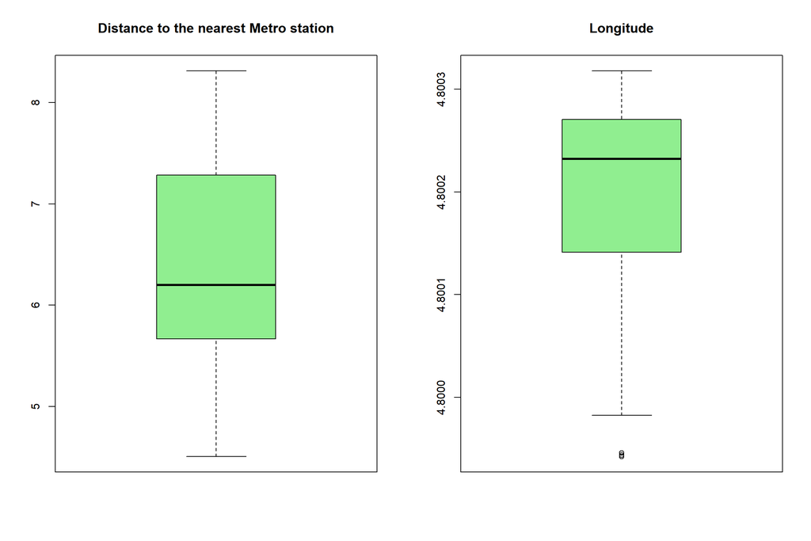

```r
df$Distance.to.the.nearest.MRT.station = log(df$Distance.to.the.nearest.MRT.station)
df$Longitude = log(df$Longitude)

par(mfrow = c(1,2))
boxplot(df$Distance.to.the.nearest.MRT.station, main = "Distance to the nearest Metro station", col='lightgreen')
boxplot(df$Longitude, main = 'Longitude', col='lightgreen')
```

We note that Outliers still remain in the Longitude column when we convert to log

So we drop the outliers rows from the dataset

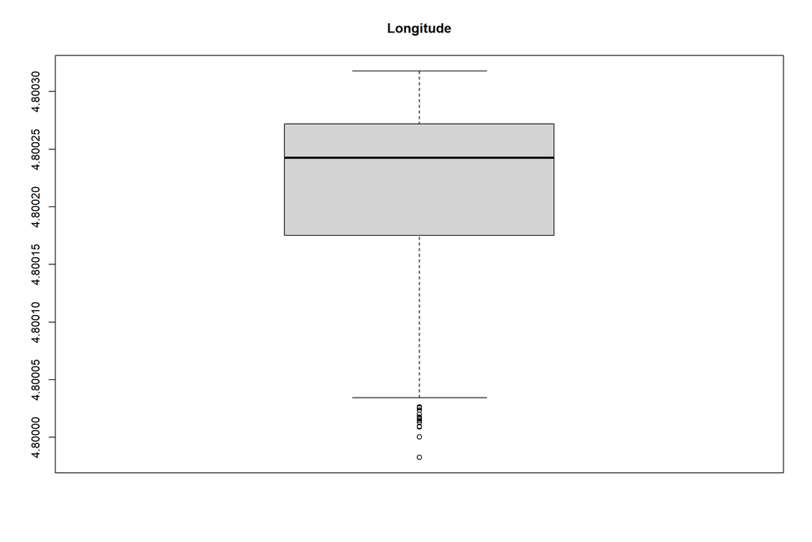

```r
par(mfrow = c(1,1))
new_data = subset(df, df$Longitude>boxplot(df$Longitude, plot= 'False')$stats[1,])
boxplot(new_data$Longitude, main="Longitude")
```

After dropping we see that the outliers increased. So we just use the previous plot without removing the outliers as there are only 3 outlying points

# Assumption 1:

Linear relationship between dependent and independent variables. Checking this assumption by plotting each dependent variable against dependent variable in a scatter plot.

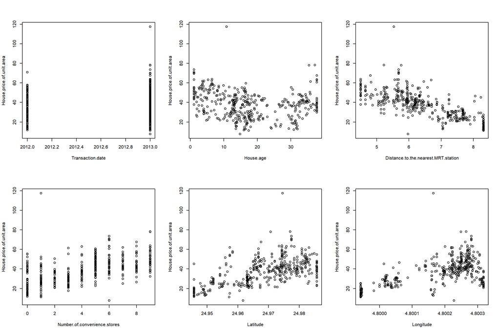

```r
par(mfrow = c(2,3))
plot(House.price.of.unit.area ~ Transaction.date,data=df)
plot(House.price.of.unit.area ~ House.age,data=df)
plot(House.price.of.unit.area ~ Distance.to.the.nearest.MRT.station,data=df)
plot(House.price.of.unit.area ~ Number.of.convenience.stores,data=df)
plot(House.price.of.unit.area ~ Latitude,data=df)
plot(House.price.of.unit.area ~ Longitude,data=df)
```

We see that:

Transaction date does not have a linear relationship with house price

House age is pretty scattered and no significant relationship can be seen between the independent and dependent variables

Distance to the nearest metro station has a negative linear relationship with house price meaning that the price of the house increases the closer it is to a metro station

Number of convenience stores has a positive linear relationship with house price meaning the price increases with the increase in number of stores in its vacinity

Longitude and Latitude also have a significant effect on the price of the house

# Assumption 2:

Independent Variables are not highly correlated

```r
correlation <- cor(df[1:6])
correlation>0.8
```

```
##                                     Transaction.date House.age
## Transaction.date                                TRUE     FALSE
## House.age                                      FALSE      TRUE
## Distance.to.the.nearest.MRT.station            FALSE     FALSE
## Number.of.convenience.stores                   FALSE     FALSE
## Latitude                                       FALSE     FALSE
## Longitude                                      FALSE     FALSE
##                                     Distance.to.the.nearest.MRT.station
## Transaction.date                                                  FALSE
## House.age                                                         FALSE
## Distance.to.the.nearest.MRT.station                                TRUE
## Number.of.convenience.stores                                      FALSE
## Latitude                                                          FALSE
## Longitude                                                         FALSE
##                                     Number.of.convenience.stores Latitude
## Transaction.date                                           FALSE    FALSE
## House.age                                                  FALSE    FALSE
## Distance.to.the.nearest.MRT.station                        FALSE    FALSE
## Number.of.convenience.stores                                TRUE    FALSE
## Latitude                                                   FALSE     TRUE
## Longitude                                                  FALSE    FALSE
##                                     Longitude
## Transaction.date                        FALSE
## House.age                               FALSE
## Distance.to.the.nearest.MRT.station     FALSE
## Number.of.convenience.stores            FALSE
## Latitude                                FALSE
## Longitude                                TRUE
```

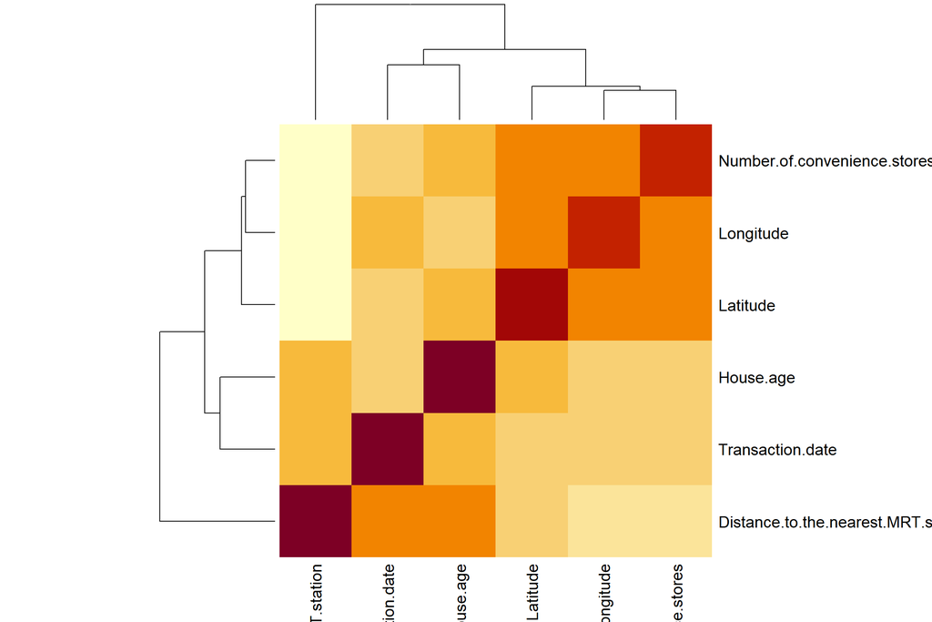

```r
heatmap(correlation)
```

As we can see, there is no high correlation between the independent Variables

#VIF

```r
df.lm<-lm(House.price.of.unit.area ~Distance.to.the.nearest.MRT.station+Number.of.convenience.stores+Latitude+Longitude,data=df)
```

Checking multicollinearity We use the VIF test to check for multicollinearity

```r
VIF(df.lm)[VIF(df.lm)>5]
```

```
## named numeric(0)
```

# Assumption 3:

Variance of residuals is constant.

We use the plot of standardized residuals against predicted values to check for the variance

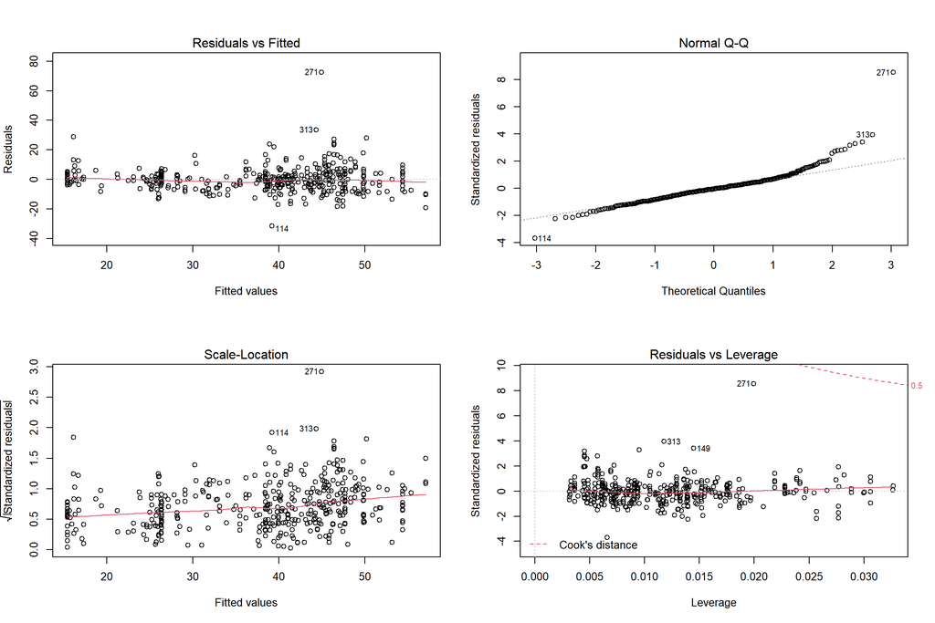

```r
par(mfrow=c(2,2))
plot(df.lm)
```

here we see that the variance of observations is constant

# Assumption 4:

Independence of Observations

The Durbin-Watson Statistic shows the autocorrelation between observations

It ranges from 0 to 4.

0-2 indicates a positive autocorrelation

2 indicates no autocorrelation

2-4 indicates a negative autocorrelation

```r
dwtest(df.lm)
```

```
##
##  Durbin-Watson test
##
## data:  df.lm
## DW = 2.1437, p-value = 0.9293
## alternative hypothesis: true autocorrelation is greater than 0
```

Since the DW statistic is close to 2 and the p-value is higher than 0.05, we fail to reject the null hypothesis that there is no autocorrelation between the observations

# Assumption 5

Multivariate normality

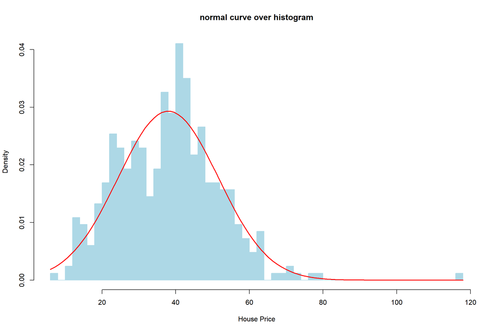

```r
g = df$House.price.of.unit.area
m<-mean(g)
std<-sqrt(var(g))
hist(g, breaks=50, prob='True',
     xlab="House Price",
     main="normal curve over histogram", col='lightblue', border = 'lightblue')
curve(dnorm(x, mean=m, sd=std),
      col="red", lwd=2, add=TRUE, yaxt="n")
```

We can see that the price variable is pretty much normally distributed.

# Model and variable selection

```r
summary(df.lm)
```

```
##
## Call:
## lm(formula = House.price.of.unit.area ~ Distance.to.the.nearest.MRT.station +
##     Number.of.convenience.stores + Latitude + Longitude, data = df)
##
## Residuals:
##     Min      1Q  Median      3Q     Max
## -31.608  -4.644  -0.472   3.479  72.516
##
## Coefficients:
##                                       Estimate Std. Error t value Pr(>|t|)
## (Intercept)                         -2.136e+04  2.487e+04  -0.859    0.391
## Distance.to.the.nearest.MRT.station -7.003e+00  6.623e-01 -10.575  < 2e-16 ***
## Number.of.convenience.stores         2.525e-01  2.059e-01   1.226    0.221
## Latitude                             3.195e+02  4.461e+01   7.162 3.71e-12 ***
## Longitude                            2.804e+03  5.211e+03   0.538    0.591
## ---
## Signif. codes:  0 '***' 0.001 '**' 0.01 '*' 0.05 '.' 0.1 ' ' 1
##
## Residual standard error: 8.579 on 409 degrees of freedom
## Multiple R-squared:  0.6063, Adjusted R-squared:  0.6025
## F-statistic: 157.5 on 4 and 409 DF,  p-value: < 2.2e-16
```

Distance.to.the.nearest.MRT.station and Latitude are the variables that we will select for Multiple linear regression as we can see from above summary that the probability of each of these parameters’ slope with respect to House.price.of.unit.area to be 0 is significantly lower than 1%

```r
df.lm<-lm(House.price.of.unit.area ~Distance.to.the.nearest.MRT.station+Latitude,data=df)
summary(df.lm)
```

```
##
## Call:
## lm(formula = House.price.of.unit.area ~ Distance.to.the.nearest.MRT.station +
##     Latitude, data = df)
##
## Residuals:
##     Min      1Q  Median      3Q     Max
## -31.168  -4.545  -0.464   3.679  71.070
##
## Coefficients:
##                                       Estimate Std. Error t value Pr(>|t|)
## (Intercept)                         -8241.8411  1081.5134  -7.621 1.76e-13 ***
## Distance.to.the.nearest.MRT.station    -7.6037     0.4536 -16.762  < 2e-16 ***
## Latitude                              333.5522    43.2557   7.711 9.50e-14 ***
## ---
## Signif. codes:  0 '***' 0.001 '**' 0.01 '*' 0.05 '.' 0.1 ' ' 1
##
## Residual standard error: 8.577 on 411 degrees of freedom
## Multiple R-squared:  0.6046, Adjusted R-squared:  0.6027
## F-statistic: 314.2 on 2 and 411 DF,  p-value: < 2.2e-16
```

Adjusted R-squared is a statistical measure that accounts for the number of independent variables in a linear regression model and provides an adjusted estimate of the proportion of the variance in the dependent variable that is explained by the model. #Adjusted R^2 is 0.6027 Which means, our model explains the variables with 60.27% accuracy